# Visualización de datos en R

Actividad práctica

# 1 Gráficos en R

- El paquete por default para hacer gráficas en `R` se llama `graphics`.
- Viene instalado con las librerías básicas de `R`.
- Tiene una gran versatilidad y produce buenas gráficas.

## 1.1 Qué es ggplot2?

- `ggplot` es una librería que se genera a partir de la [tesis doctoral de Hadley Wickham](http://had.co.nz/thesis/practical-tools-hadley-wickham.pdf).

## 1.2 Documentación

- [Oficial](https://ggplot2.tidyverse.org/index.html)
- [Extensiones](https://exts.ggplot2.tidyverse.org/)

```r
install.packages("ggplot2")
```

## 1.3 Una Gramatica de Graficas

[A Layered Grammar of Graphics](http://diytranscriptomics.com/Reading/files/layered-grammar.pdf)

## 1.4 Se trata de un sistema de capas

```
Hacer un gráfico +
  una capa de (
    Datos
    Estadísticas
    Componentes estéticos
    Geometría
  ) +
  otra capa de (
    Datos
    Estadísticas
    Componentes estéticos
    Geometría
  ) +
  retoques de la gráfica +
  estilo
```

```r
ggplot(...) +
  layer(...) +
  layer(...) +
  helper(...) +
  helper(...) +
  theme(...)
```

## 1.5 veamos como funciona

```r
ggplot() +
  layer(
    data = diamonds,
    mapping = aes(x = carat, y = price),
    geom = "point",
    stat = "identity",
    position = "identity"
    ) +
  scale_y_continuous() +
  scale_x_continuous() +
  coord_cartesian() +
  theme_minimal()
```

```r
ggplot() +
  layer(
    data = mtcars,
    mapping = aes(x = mpg, y = cyl),
    geom = "point",
    stat = "identity",
    position = "identity"
    ) +
  scale_y_continuous() +
  scale_x_continuous() +
  coord_cartesian() +
  theme_minimal()
```

```r
ggplot() +
  layer(
    data = diamonds,
    mapping = aes(x = carat, y = price),
    geom = "point",
    stat = "identity",
    position = "identity"
    ) +
  layer(
    data = mtcars,
    mapping = aes(x = mpg, y = cyl),
    geom = "point",
    stat = "identity",
    position = "identity"
    ) +
  scale_y_continuous() +
  scale_x_continuous() +
  coord_cartesian() +
  theme_minimal()
```

## 1.6 La gente no comprende esto

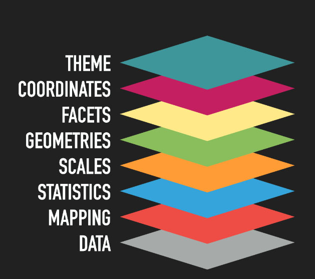

## 1.7 íbamos acá

```r
ggplot() +
  layer(
    data = diamonds,
    mapping = aes(x = carat, y = price),
    geom = "point",
    stat = "identity",
    position = "identity"
    ) +
  scale_y_continuous() +
  scale_x_continuous() +
  coord_cartesian() +
  theme_minimal()
```

```r
ggplot(
  data = diamonds,
  mapping = aes(x = carat, y = price),
) +
  layer(
    geom = "point",
    stat = "identity",
    position = "identity"
  ) +
  scale_y_continuous() +
  scale_x_continuous() +
  coord_cartesian() +
  theme_minimal()
```

```r
ggplot(
  data = diamonds,
  mapping = aes(x = carat, y = price),
) +
  layer(
    geom = "smooth",
    stat = "smooth",
    position = "identity",
    params = list(se = TRUE, colour = "#ac4875")
  ) +
  scale_y_continuous() +
  scale_x_continuous() +
  coord_cartesian() +
  theme_minimal()
```

```r
ggplot(
  data = diamonds,
  mapping = aes(x = carat, y = price),
) +
  layer(
    geom = "point",
    stat = "identity",
    position = "identity"
  ) +
  layer(
    geom = "smooth",
    stat = "smooth",
    position = "identity",
    params = list(se = TRUE, colour = "#ac4875")
  ) +
  scale_y_continuous() +
  scale_x_continuous() +
  coord_cartesian() +
  theme_minimal()
```

```r
ggplot(
  data = diamonds,
  mapping = aes(x = carat, y = price),
) +
  geom_point() +
  layer(
    geom = "smooth",
    stat = "smooth",
    position = "identity",
    params = list(se = TRUE, colour = "#ac4875")
  ) +
  scale_y_continuous() +
  scale_x_continuous() +
  coord_cartesian() +
  theme_minimal()
```

```r
ggplot(
  data = diamonds,
  mapping = aes(x = carat, y = price),
) +
  geom_point() +
  stat_smooth(colour = "#ac4875") +
  scale_y_continuous() +
  scale_x_continuous() +
  coord_cartesian() +
  theme_minimal()
```

```r
ggplot(diamonds, aes(x = carat, y = price)) +
  geom_point() +
  stat_smooth(colour = "#ac4875") +
  theme_minimal()
```

```r
ggplot(diamonds) +
  aes(x = carat, y = price) +
  geom_point() +
  stat_smooth(colour = "#ac4875") +
  theme_minimal()
```

## 1.8 Explicación

- [Una explicación muy completa](https://ggplot2.tidyverse.org/reference/)

## 1.9 Una interfaz interesante

```r
install.packages("esquisse")
library("esquisse")
esquisser(data = diamonds)
```

## 1.10 Aunque siempre hay un mejor tutorial

[A ggplot2 Tutorial for Beautiful Plotting in R](https://cedricscherer.netlify.app/2019/08/05/a-ggplot2-tutorial-for-beautiful-plotting-in-r/)

```r
library("dplyr")
library("magrittr")
library("ggplot2")
library("knitr")
library("tidyr")
```

## 1.11 Jugando con Diamonds (1)

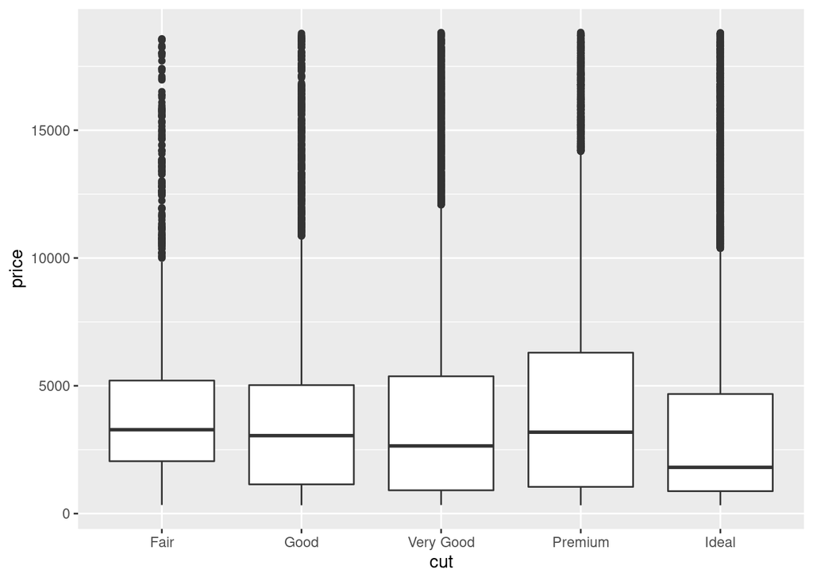

```r
ggplot(diamonds) +
  aes(x = cut, y = price) +
  geom_boxplot()
```

## 1.12 Jugando con Diamonds (2)

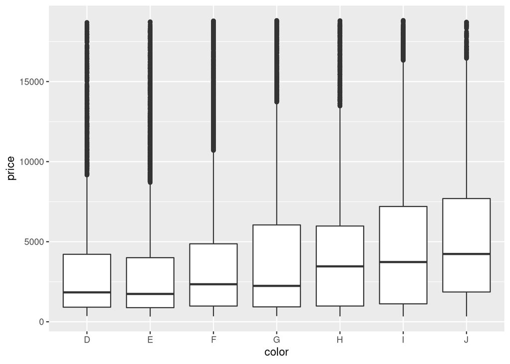

```r
ggplot(diamonds) +
  aes(x = color, y = price) +
  geom_boxplot()
```

## 1.13 Jugando con Diamonds (3)

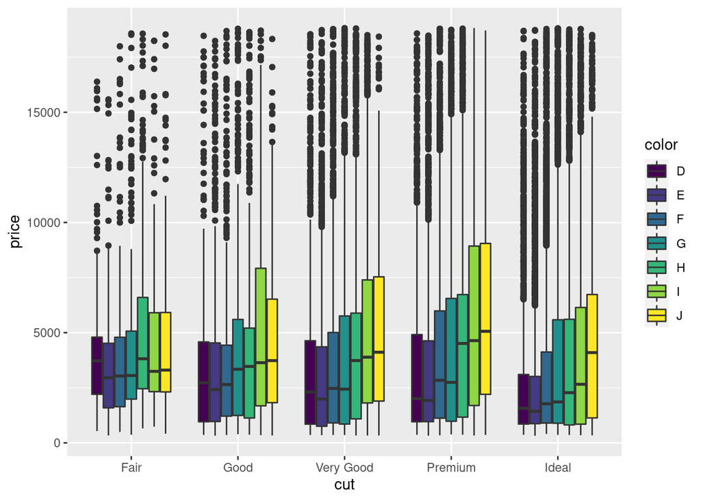

```r
ggplot(diamonds) +
  aes(x = cut, y = price, fill = color) +
  geom_boxplot()
```

## 1.14 Jugando con Diamonds (4)

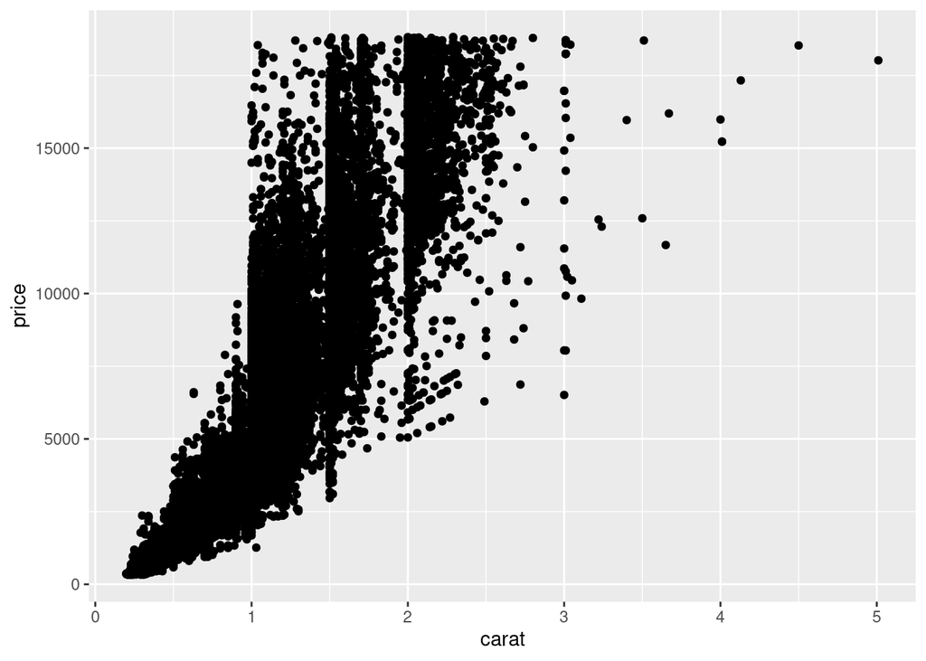

```r
ggplot(diamonds) +
  aes(x = carat, y = price) +
  geom_point()
```

## 1.15 Jugando con Diamonds (5)

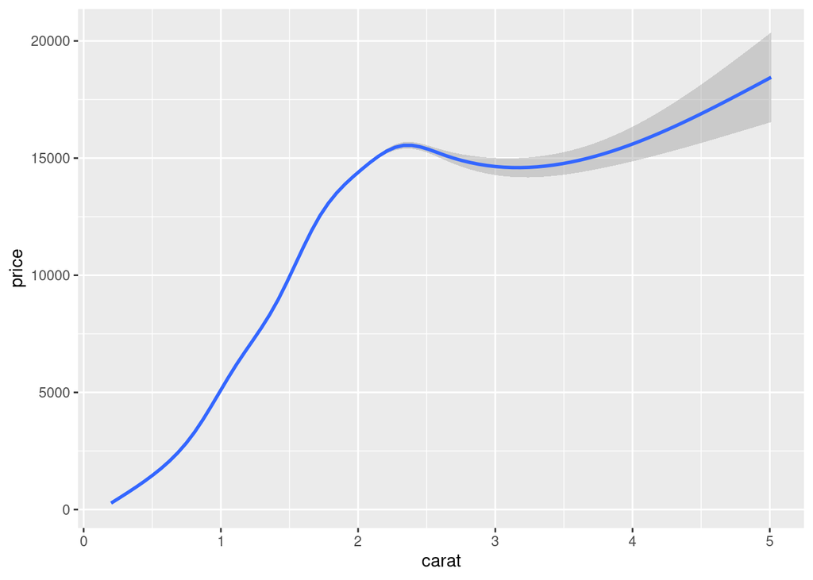

```r
ggplot(diamonds) +
  aes(x = carat, y = price) +
  geom_smooth()
```

## 1.16 Jugando con Diamonds (6)

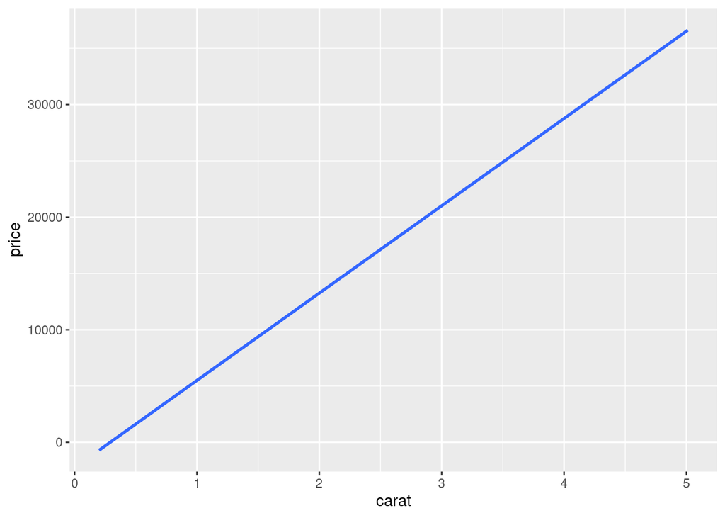

```r
ggplot(diamonds) +
  aes(x = carat, y = price) +
  geom_smooth(method = "lm")
```

## 1.17 Jugando con Diamonds (7)

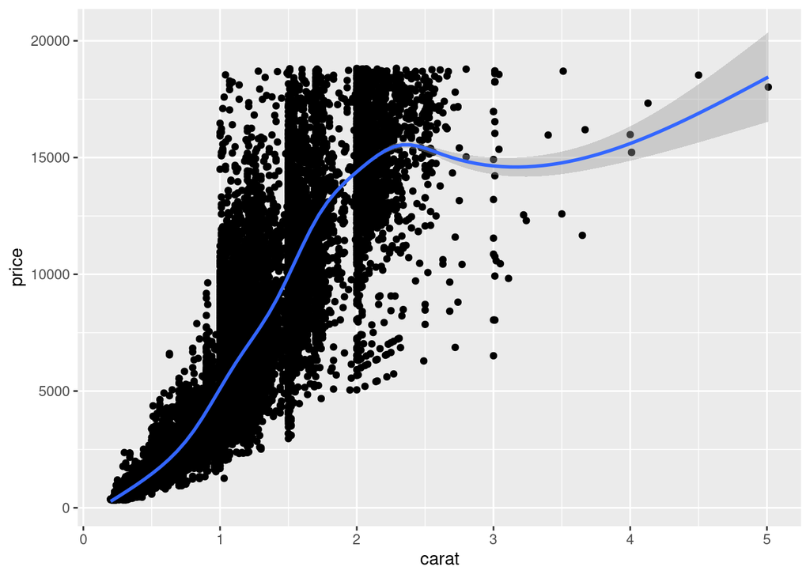

```r
ggplot(diamonds) +
  aes(x = carat, y = price) +
  geom_point() +
  geom_smooth()
```

## 1.18 Jugando con Diamonds (8)

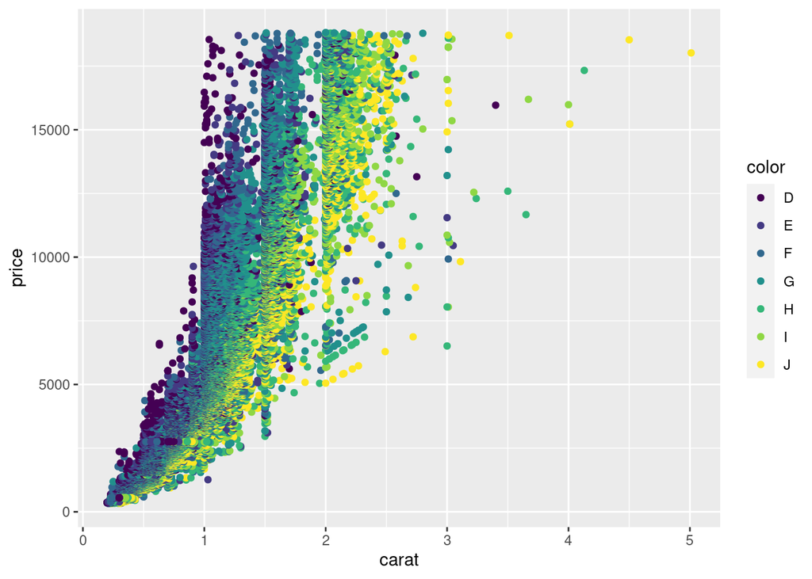

```r
ggplot(diamonds) +
  aes(x = carat, y = price, colour = color) +
  geom_point()
```

## 1.19 Jugando con Diamonds (9)

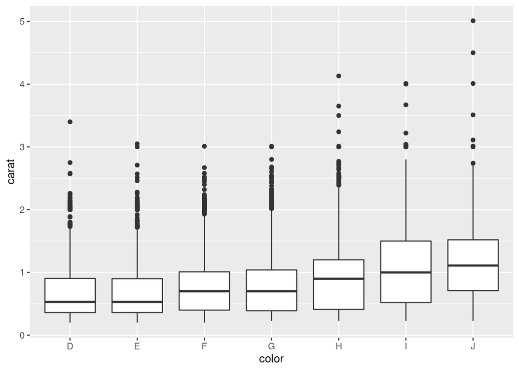

```r
ggplot(diamonds) +
  aes(x = color, y = carat) +
  geom_boxplot()
```

## 1.20 Jugando con Diamonds (10)

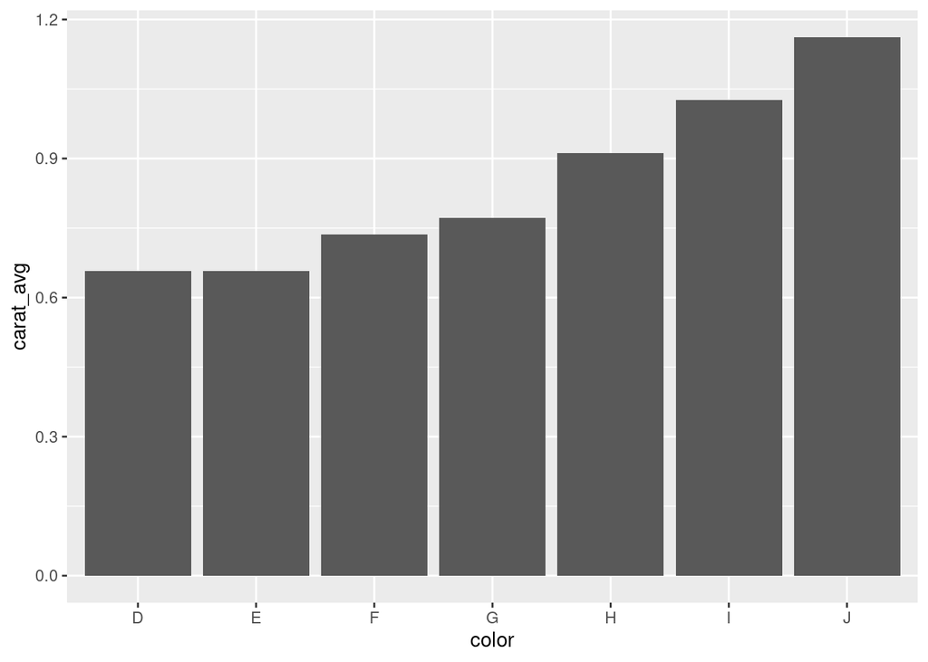

```r
diamonds %>%
  group_by(color) %>%
  summarise(carat_avg = mean(carat, na.rm = TRUE)) %>%
  ggplot() +
  aes(x = color, y = carat_avg) +
  geom_bar(stat = "identity")
```

## 1.21 Faceting

(ejercicio)

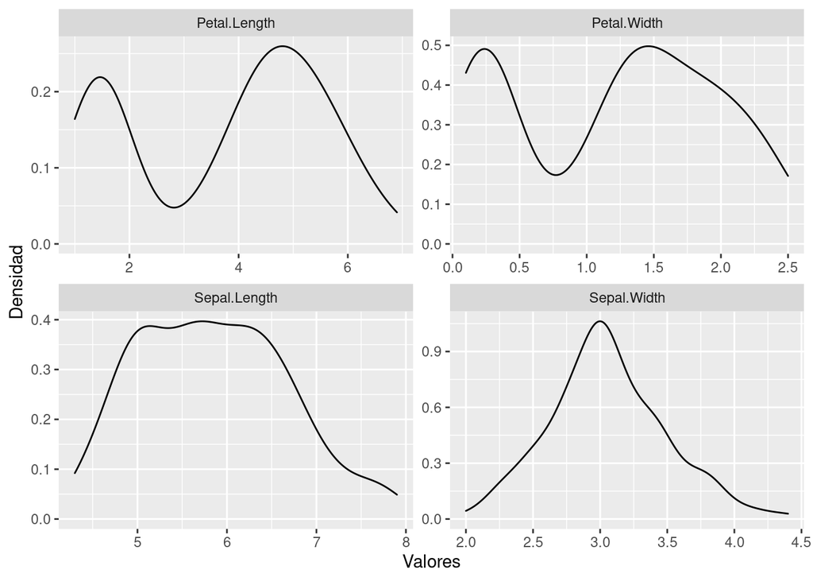

```r
iris %>%
  gather("variable", "value", -Species) %>%
  ggplot +
  aes(x = value) +
  geom_density() +
  xlab("Valores") +
  ylab("Densidad") +
  facet_wrap(~variable, scale = "free")
```

## 1.22 Faceting

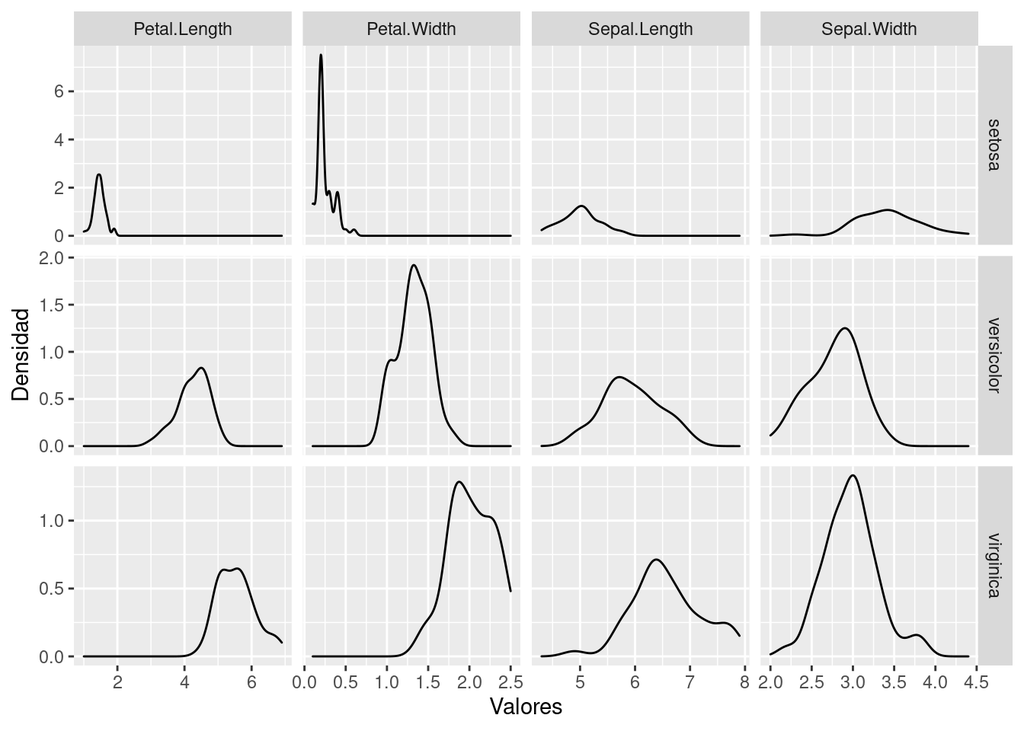

```r
iris %>%
  gather("variable", "value", -Species) %>% ggplot +
  aes(x = value) +
  geom_density() +
  xlab("Valores") +
  ylab("Densidad") +
  facet_grid(Species ~ variable, scales = "free")
```

## 1.23 The Mandelbrot Set - geom_tile

[figure not shown]

```r
# Create a grid of complex numbers
c.points <- outer(seq(-2.5, 1, by = 0.007), 1i*seq(-1.5, 1.5, by = 0.007),'+')
z <- 0
for (k in 1:30) z <- z^2 + c.points # Iterations of fractal's formula
c.points <- data.frame(reshape2::melt(c.points))
colnames(c.points) <- c("r.id", "c.id", "point")
z.points <- data.frame(reshape2::melt(z))
colnames(z.points) <- c("r.id", "c.id", "z.point")
mandelbrot <- merge(c.points, z.points, by = c("r.id","c.id")) # Mandelbrot Set
mandelbrot <- subset(mandelbrot, is.finite(-abs(z.point)))
# Plotting only finite-module numbers
ggplot(mandelbrot) +
  aes(Re(point), Im(point), fill = exp(-abs(z.point))) +
  geom_tile() +
  scale_fill_gradient(low = "#5D1A26", high = "#F02551") +
  theme(legend.position = "none", axis.title.x = element_blank(),
        axis.title.y = element_blank(),
        panel.background = element_rect(fill = "#724D53"),
        panel.grid = element_blank())
```

## 1.24 Qué gráfica elegir

[figure not shown]

## 1.25 Recomendaciones

- Al momento de crear un conjunto de gráficos que presentan algún fenómeno o situación particular, siempre se debe pensar en contar una historia
- Tenga en cuenta el contexto y la audiencia que va a recibir esta información
- Seleccionar el gráfico ideal, el que sea más efectivo en cada ocasión
- El desorden es el enemigo, muchas veces menos es más
- Enfocar la atención de la audiencia
- A la hora de construir el gráfico piense como un diseñador para comunicar con datos
- Antes de comenzar a graficar es necesario preparar la información. Como siempre es necesario tener un claro entendimiento de los datos que se van a trabajar

## 1.26 Inspiración (con códigos)

- [Galería de gráficas en R](https://www.r-graph-gallery.com/)
- [Top 50 de visualizaciones en R](http://r-statistics.co/Top50-Ggplot2-Visualizations-MasterList-R-Code.html)

## 1.27 Ejercicio práctico

Vamos a revisar diferentes bases de datos que hemos trabajado previamente, así como algunas bases de datos que ustedes han usado en los análisis y proceso de aprendizaje del diplomado.

Para cada base de datos identificaremos:

1. Variables dependientes/críticas/de mayor interés
2. Una visualización univariada para la viariable de interés
3. Una o varias visualizaciones bivariadas relacionadas con la variable de interés
4. Si podemos construir una visualización multivariada
5. Códigos necesarios para realizar dichas visualizaciones (nombre/tipo de gráfica)